# asset pricing

Olivier Bauthéac

At the time of writing, the analytics part of the pipeline in [finRes](https://bautheac.github.io/finRes/) focusses on asset pricing.

## FFresearch

The [FFresearch](https://bautheac.github.io/FFresearch/) package provides data on classic asset pricing factors and a number of sort portfolios. The data is pulled directly from Kenneth French’s [data library](http://mba.tuck.dartmouth.edu/pages/faculty/ken.french/data_library.html) and tidied up for seamless consumption in R.

### portfolios

#### univariate

The `portfolios_univariate` dataset provides various feature time series for Fama/French portfolios formed on single variable sorts. Sorting variables include size, book-to-market, operating profitability and investment:

```
#>    region frequency         sort variable dividend weights portfolio  field
#> 1:     US       day market capitalization        Y   value     Dec 2 return
#> 2:     US       day market capitalization        Y   value     Dec 2 return
#> 3:     US       day market capitalization        Y   value     Dec 2 return
#> 4:     US       day market capitalization        Y   value     Dec 2 return
#> 5:     US       day market capitalization        Y   value     Dec 2 return
#> 6:     US       day market capitalization        Y   value     Dec 2 return
#>      period value
#> 1: 19710104 -0.29
#> 2: 19710105  1.65
#> 3: 19710106  1.37
#> 4: 19710107  0.11
#> 5: 19710108 -0.19
#> 6: 19710111  0.47
```

#### bivariate

The `portfolios_bivariate` dataset provides various feature time series for Fama/French portfolios formed on two variable sorts. Sorting variables include size, book-to-market, operating profitability and investment:

```
#>    region frequency       sort variable 1 sort variable 2 dividend weights
#> 1:     US       day market capitalization     book/market        Y   value
#> 2:     US       day market capitalization     book/market        Y   value
#> 3:     US       day market capitalization     book/market        Y   value
#> 4:     US       day market capitalization     book/market        Y   value
#> 5:     US       day market capitalization     book/market        Y   value
#> 6:     US       day market capitalization     book/market        Y   value
#>    portfolio  field   period value
#> 1:  BIG HiBM return 20110103  4.81
#> 2:  BIG HiBM return 20110104  0.16
#> 3:  BIG HiBM return 20110105  1.80
#> 4:  BIG HiBM return 20110106 -0.40
#> 5:  BIG HiBM return 20110107 -0.71
#> 6:  BIG HiBM return 20110110  0.23
```

#### trivariate

The `portfolios_trivariate` dataset provides various feature time series for Fama/French portfolios formed on three variable sorts. Sorting variables include size, book-to-market, operating profitability and investment:

```
#>    region frequency       sort variable 1 sort variable 2
#> 1:     US     month market capitalization     book/market
#> 2:     US     month market capitalization     book/market
#> 3:     US     month market capitalization     book/market
#> 4:     US     month market capitalization     book/market
#> 5:     US     month market capitalization     book/market
#> 6:     US     month market capitalization     book/market
#>            sort variable 3 dividend weights     portfolio  field period   value
#> 1: operating profitability        Y   value BIG HiBM.HiOP return 197101 18.7986
#> 2: operating profitability        Y   value BIG HiBM.HiOP return 197102  4.1366
#> 3: operating profitability        Y   value BIG HiBM.HiOP return 197103  0.6142
#> 4: operating profitability        Y   value BIG HiBM.HiOP return 197104  0.9330
#> 5: operating profitability        Y   value BIG HiBM.HiOP return 197105  2.6881
#> 6: operating profitability        Y   value BIG HiBM.HiOP return 197106  0.7549
```

#### industries

The `portfolios_industries` dataset provides various feature time series for Fama/French industry portfolios (Fama and French 1997):

```
#>    region frequency dividend weights portfolio  field period value
#> 1:     US     month        Y   value      Aero return 197101 20.39
#> 2:     US     month        Y   value      Aero return 197102  4.36
#> 3:     US     month        Y   value      Aero return 197103  2.49
#> 4:     US     month        Y   value      Aero return 197104  6.54
#> 5:     US     month        Y   value      Aero return 197105 -4.19
#> 6:     US     month        Y   value      Aero return 197106 -1.92
```

### factors

The `factors` dataset provides the return (factors) and level (risk free rate) time series for the classic Fama/French asset pricing factors as used in their three (Fama and French 1992, 1993, 1995) and most recently five-factor (Fama and French 2015, 2016, 2017) asset pricing models very popular to the asset pricing enthusiasts:

```
#>    region frequency factor period value
#> 1:     US     month    CMA 197101 -0.14
#> 2:     US     month    CMA 197102 -0.72
#> 3:     US     month    CMA 197103 -2.69
#> 4:     US     month    CMA 197104  0.72
#> 5:     US     month    CMA 197105  0.30
#> 6:     US     month    CMA 197106 -1.74
```

### variables

The `variables` dataset is a helper dataset that provides details, including construction methods, for the variables used to construct the portfolios and asset pricing factors above:

```
#> # A tibble: 6 x 3
#>   name              symbol description
#>   <chr>             <chr>  <chr>
#> 1 market capitaliz… ME     Market equity (size) is price times shares outstandi…
#> 2 book value        BE     Book equity is constructed from Compustat data or co…
#> 3 book/market       ME/BE  The book-to-market ratio used to form portfolios in …
#> 4 operating profit… OP     The operating profitability ratio used to form portf…
#> 5 investment        INV    The investment ratio used to form portfolios in June…
#> 6 earnings/price    E/P    Earnings is total earnings before extraordinary item…
```

### breakpoints

The `breakpoints` dataset is a helper dataset that provides the times series for the variables breakpoints used to construct the variables that in turn allow the construction of the portfolios and asset pricing factors above-mentioned:

```
#>    variable frequency percentile period   value
#> 1:     size     month # positive 202104 1142.00
#> 2:     size     month         5% 202104  191.41
#> 3:     size     month        10% 202104  469.18
#> 4:     size     month        15% 202104  689.71
#> 5:     size     month        20% 202104 1035.99
#> 6:     size     month        25% 202104 1466.86
```

## factors

Meanwhile, the [factors](https://bautheac.github.io/factors/) package provides various asset pricing research factor time series for convenient consumption in R with the data directly pulled from the authors’ website. The current version includes the factor data from Kenneth’s French, also available in the [FFresearch](https://bautheac.github.io/FFresearch/) package described above, as well as factor data from Robert F. Stambaugh.

```r
library(factors)

data(list = c("fama_french", "stambaugh"), package = "factors")
```

### Fama & French

The `fama_french` dataset provides the return (factors) and level (risk free rate) time series for the classic Fama/French asset pricing factors as used in their three (Fama and French 1992, 1993, 1995) and most recently five-factor (Fama and French 2015, 2016, 2017) asset pricing models very popular to the asset pricing enthusiasts:

```
#>    region frequency factor period value
#> 1:     US     month    CMA 197101 -0.14
#> 2:     US     month    CMA 197102 -0.72
#> 3:     US     month    CMA 197103 -2.69
#> 4:     US     month    CMA 197104  0.72
#> 5:     US     month    CMA 197105  0.30
#> 6:     US     month    CMA 197106 -1.74
```

### Stambaugh et al

The `stambaugh` dataset provides the return (factors) and level (risk free rate) time series for various research asset pricing factors put together by Robert F. Stambaugh and collaborators including Lubos Pastor and Yu Yuan. The factors include traded & non-traded liquidity (Pástor and Stambaugh 2003), as well as market, size and two ‘mispricing’ factors: management & performance (Stambaugh and Yuan 2016):

```
#>    frequency               factor period       value
#> 1:     month non-traded liquidity 196208  0.00426023
#> 2:     month non-traded liquidity 196209  0.01172080
#> 3:     month non-traded liquidity 196210 -0.07442466
#> 4:     month non-traded liquidity 196211  0.02854555
#> 5:     month non-traded liquidity 196212  0.01435009
#> 6:     month non-traded liquidity 196301  0.00947839
```

## factor’em!

[factorem](https://bautheac.github.io/factorem/) on the other hand provides tools for outright factor construction from data retrieved with [pullit](https://bautheac.github.io/pullit/) that facilitate asset pricing research and factor investment backtesting. The returned objects carry corresponding return & positions time series and a number of methods help with performance analysis. The package is organised around a workhorse function and a series of wrappers for asset pricing factors popular in the literature. The latter functions get raw financial data retrieved from Bloomberg using the [pullit](https://bautheac.github.io/pullit/) package and return S4 objects that carry data belonging to the corresponding factor including positions and return time series.

### factorem

The `factorem` function is the workhorse function in [factorem](https://bautheac.github.io/factorem/). From raw financial data and a set of parameter specifications it constructs a complete backtest of the corresponding asset pricing factor and returns the whole time series for the factor positions and return. For the record the S4 object returned by the function also contains the original raw financial and the set of parameters supplied as well as the original call to the function. The raw financial data should be supplied in a format similar to that of historical datasets returned returned by historical data query functions in [pullit](https://bautheac.github.io/pullit/):

```r
library(pullit); library(lubridate)

tickers_equity <- c("LZB US Equity", "SGA US Equity", "AGCO US Equity", "CLR US Equity",
                    "GHC US Equity", "MAN US Equity", "SITE US Equity", "AJRD US Equity",
                    "COMM US Equity", "GME US Equity", "MEI US Equity", "SMP US Equity")
start <- "2016-01-01"; end <- "2017-12-31"

equity_data_market <- pull_equity_market(source = "Bloomberg", tickers_equity, start, end, verbose = F)

get_data(equity_data_market)
```

```
#>                ticker       field       date      value
#>     1: AGCO US Equity CUR_MKT_CAP 2016-11-21   4271.793
#>     2: AGCO US Equity CUR_MKT_CAP 2016-11-22   4360.889
#>     3: AGCO US Equity CUR_MKT_CAP 2016-11-23   4507.777
#>     4: AGCO US Equity CUR_MKT_CAP 2016-11-25   4535.067
#>     5: AGCO US Equity CUR_MKT_CAP 2016-11-28   4518.211
#>    ---
#> 33466:  SMP US Equity   PX_VOLUME 2017-12-22  89626.000
#> 33467:  SMP US Equity   PX_VOLUME 2017-12-26  48762.000
#> 33468:  SMP US Equity   PX_VOLUME 2017-12-27 119607.000
#> 33469:  SMP US Equity   PX_VOLUME 2017-12-28  81731.000
#> 33470:  SMP US Equity   PX_VOLUME 2017-12-29 153615.000
```

From there, construct a bespoke asset pricing factor using the factorem function. I.e., an equity momentum factor:

```r
library(factorem)

ranking_period = 1L

factor <- factorem(
  name = "momentum", data = pullit::get_data(equity_data_market),
  sort_levels = FALSE, weighted = FALSE, ranking_period = ranking_period
  )
factor
```

```
#> AssetPricingFactor
#>   name: momentum factor
#>   parameters
#>     name:         momentum
#>     update frequency:     month
#>     return frequency:     day
#>     price variable:   PX_LAST
#>     sort variable:    PX_LAST
#>     sort levels:  FALSE
#>     weighted:         FALSE
#>     ranking period:   1
#>     long threshold:   0.5
#>     short threshold:  0.5
```

### wrappers

[factorem](https://bautheac.github.io/factorem/) provides wrapper methods for popular asset pricing factors in the literature. At the time of writing the factors covered in the package include, equity market and momentum as well as futures market, momentum, commercial hedging pressure (CHP), open interest and term structure factors. The author welcomes pull requests that would help expanding the current coverage.

#### equity

##### **market**

The equity market factor encompasses the entire cross-section of a defined investment opportunity set. It gained popularity in the 1960s for the central role it plays in the Capital Asset Pricing Model (Treynor 1961a, 1961b; Sharpe 1964; Mossin 1966; Lintner 1975) and remains the most popular factor to date in the literature when it comes to explaining the cross-section of equity returns:

```r
equity_market <- market_factor(data = equity_data_market)
equity_market
```

```
#> MarketFactor
#>   name: equity market factor
#>   parameters
#>     return frequency:     month
#>     long:         TRUE
```

##### **momentum**

The equity momentum factor is another popular factor in the asset pricing literature. After being first introduced in Carhart (1997) it eventually drew the field leaders’ attention in Fama and French (2012) The equity momentum sorts on prior returns over a defined ranking period:

```r
equity_momentum <- momentum_factor(data = equity_data_market, ranking_period = ranking_period)
equity_momentum
```

```
#> MomentumFactor
#>   name: equity momentum factor
#>   parameters
#>     name:         equity momentum
#>     update frequency:     week
#>     return frequency:     day
#>     price variable:   PX_LAST
#>     sort variable:    PX_LAST
#>     sort levels:  FALSE
#>     weighted:         FALSE
#>     ranking period:   1
#>     long threshold:   0.5
#>     short threshold:  0.5
```

#### futures

```r
tickers_futures <- c(
  "C A Comdty", "CLA Comdty", "COA Comdty", "GCA Comdty", "HOA Comdty",
  "KWA Comdty", "LHA Comdty", "QSA Comdty", "S A Comdty", "SBA Comdty",
  "W A Comdty"
  )

futures_data_TS <- pull_futures_market(source = "Bloomberg", type = "term structure", tickers_futures,
                                       start, end, verbose = F)

get_data(futures_data_TS)
```

```
#>                      ticker     field       date  value
#>      1: C 1 A:00_0_N Comdty  OPEN_INT 2016-01-04 727298
#>      2: C 1 A:00_0_N Comdty  OPEN_INT 2016-01-05 730600
#>      3: C 1 A:00_0_N Comdty  OPEN_INT 2016-01-06 727995
#>      4: C 1 A:00_0_N Comdty  OPEN_INT 2016-01-07 727244
#>      5: C 1 A:00_0_N Comdty  OPEN_INT 2016-01-08 719406
#>     ---
#> 239938: W 5 A:00_0_N Comdty PX_VOLUME 2017-12-22   4135
#> 239939: W 5 A:00_0_N Comdty PX_VOLUME 2017-12-26   2339
#> 239940: W 5 A:00_0_N Comdty PX_VOLUME 2017-12-27   1129
#> 239941: W 5 A:00_0_N Comdty PX_VOLUME 2017-12-28   1657
#> 239942: W 5 A:00_0_N Comdty PX_VOLUME 2017-12-29   1617
```

##### **market**

[factorem](https://bautheac.github.io/factorem/) provides futures equivalent for the factors above including a futures market factor that takes equally weighted positions on the nearby front contract of the commodity futures series provided:

```r
futures_market <- market_factor(data = futures_data_TS)
futures_market
```

```
#> MarketFactor
#>   name: futures nearby market factor
#>   parameters
#>     return frequency:     month
#>     long:         TRUE
```

##### **momentum**

The momentum factor is also popular in the futures asset pricing literature in particular in the context of commodity markets (Miffre and Rallis 2007). As does its equity equivalent, it sorts on prior returns:

```r
ranking_period = 1L
futures_momentum <- momentum_factor(data = futures_data_TS, ranking_period = ranking_period)
futures_momentum
```

```
#> MomentumFactor
#>   name: futures momentum factor
#>   parameters
#>     name:         futures momentum
#>     update frequency:     week
#>     return frequency:     day
#>     price variable:   PX_LAST
#>     sort variable:    PX_LAST
#>     sort levels:  FALSE
#>     weighted:         FALSE
#>     ranking period:   1
#>     long threshold:   0.5
#>     short threshold:  0.5
```

##### **commercial hedging pressure** (**CHP**)

The futures commercial hedging pressure factor is based on the well-known hedging pressure-based theory (Keynes 1930; Hicks 1939; Houthakker 1957; Cootner 1960) which postulates that futures prices for a given commodity are inversely related to the extent that commercial hedgers are short or long and the mimicking portfolio here aims at capturing the impact of hedging pressure as a systemic factor (Basu and Miffre 2013).

```r
futures_data_CFTC <- pull_futures_CFTC(source = "Bloomberg", tickers_futures, start, end, verbose = F)

ranking_period = 1L
futures_CHP <- CHP_factor(price_data = futures_data_TS, CHP_data = futures_data_CFTC,
                          ranking_period = ranking_period)
futures_CHP
```

```
#> CHPFactor
#>   name: CHP factor
#>   parameters
#>     name:         CHP
#>     update frequency:     month
#>     return frequency:     day
#>     price variable:   PX_LAST
#>     sort variable:    inverse CHP
#>     sort levels:  TRUE
#>     weighted:         FALSE
#>     ranking period:   1
#>     long threshold:   0.5
#>     short threshold:  0.5
```

##### **open interest**

The open interest factor relates to futures market liquidity and is also present in the literature where it is described as having explanatory power on the cross-section of commodity futures returns (Hong and Yogo 2012). It comes in two flavours in factorem, nearby and aggregate.

###### **nearby**

The nearby open interest factor is concerned with liquidity at the very front end of the term structure where it sorts on nearby front contract’s open interest:

```r
ranking_period = 1L
futures_OI_nearby <- OI_nearby_factor(data = futures_data_TS, ranking_period = ranking_period)
futures_OI_nearby
```

```
#> OIFactor
#>   name: nearby OI factor
#>   parameters
#>     name:         nearby OI
#>     update frequency:     month
#>     return frequency:     day
#>     price variable:   PX_LAST
#>     sort variable:    OPEN_INT
#>     sort levels:  FALSE
#>     weighted:         FALSE
#>     ranking period:   1
#>     long threshold:   0.5
#>     short threshold:  0.5
```

###### **aggregate**

In contrast, the aggregate open interest factor is concerned with term structure liquidity as a whole and sorts on open interest summed up over all the contracts of a particular futures series:

```r
futures_data_agg <- pull_futures_market(source = "Bloomberg", type = "aggregate", tickers_futures,
                                        start, end, verbose = F)

ranking_period = 1L
futures_OI_aggregate <- OI_aggregate_factor(price_data = futures_data_market,
                                            aggregate_data = futures_data_agg,
                                            ranking_period = ranking_period)
futures_OI_aggregate
```

```
#> OIFactor
#>   name: aggregate OI factor
#>   parameters
#>     name:         aggregate OI
#>     update frequency:     month
#>     return frequency:     day
#>     price variable:   PX_LAST
#>     sort variable:    FUT_AGGTE_OPEN_INT
#>     sort levels:  FALSE
#>     weighted:         FALSE
#>     ranking period:   1
#>     long threshold:   0.5
#>     short threshold:  0.5
```

##### **term structure**

The futures term structure factor (Szymanowska et al. 2014; Fuertes, Miffre, and Fernandez-Perez 2015) is concerned with the shape (steepness) of the futures term structure and sorts on roll yield:

```r
ranking_period = 1L
futures_TS <- TS_factor(data = futures_data_TS, ranking_period = ranking_period)
futures_TS
```

```
#> TSFactor
#>   name: futures term structure factor
#>   parameters
#>     name:         futures term structure
#>     update frequency:     month
#>     return frequency:     day
#>     price variable:   PX_LAST
#>     sort variable:    carry
#>     sort levels:  TRUE
#>     weighted:         FALSE
#>     ranking period:   1
#>     long threshold:   0.5
#>     short threshold:  0.5
```

### accessors

```r
get_name(factor)
```

```
#> [1] "momentum"
```

#### positions

```r
get_positions(factor)
```

```
#>            date          name position
#>   1: 2016-12-30 LZB US Equity     long
#>   2: 2016-12-30 MEI US Equity     long
#>   3: 2016-12-30 SMP US Equity     long
#>   4: 2016-12-30 SGA US Equity     long
#>   5: 2016-12-30 GHC US Equity     long
#>  ---
#> 152: 2017-12-29 SGA US Equity    short
#> 153: 2017-12-29 LZB US Equity    short
#> 154: 2017-12-29 GME US Equity    short
#> 155: 2017-12-29 GHC US Equity    short
#> 156: 2017-12-29 MAN US Equity    short
```

#### returns

```r
get_returns(factor)
```

```
#>            date          long         short        factor
#>   1: 2017-01-03  0.0135047148 -0.0109830009  0.0012608570
#>   2: 2017-01-04  0.0143650103 -0.0218710531 -0.0037530214
#>   3: 2017-01-05 -0.0324683966  0.0101188617 -0.0111747674
#>   4: 2017-01-06  0.0009696990  0.0112154077  0.0060925534
#>   5: 2017-01-09 -0.0068085180  0.0063287768 -0.0002398706
#>  ---
#> 247: 2017-12-22 -0.0007898250  0.0101846620  0.0046974185
#> 248: 2017-12-26  0.0093618073  0.0063778750  0.0078698411
#> 249: 2017-12-27 -0.0001223505 -0.0012346003 -0.0006784754
#> 250: 2017-12-28 -0.0001494908  0.0008308516  0.0003406804
#> 251: 2017-12-29 -0.0059587926  0.0079990948  0.0010201511
```

#### data initially supplied

```r
factorem::get_data(factor)
```

```
#>                ticker       field       date      value
#>     1: AGCO US Equity CUR_MKT_CAP 2016-11-21   4271.793
#>     2: AGCO US Equity CUR_MKT_CAP 2016-11-22   4360.889
#>     3: AGCO US Equity CUR_MKT_CAP 2016-11-23   4507.777
#>     4: AGCO US Equity CUR_MKT_CAP 2016-11-25   4535.067
#>     5: AGCO US Equity CUR_MKT_CAP 2016-11-28   4518.211
#>    ---
#> 33466:  SMP US Equity   PX_VOLUME 2017-12-22  89626.000
#> 33467:  SMP US Equity   PX_VOLUME 2017-12-26  48762.000
#> 33468:  SMP US Equity   PX_VOLUME 2017-12-27 119607.000
#> 33469:  SMP US Equity   PX_VOLUME 2017-12-28  81731.000
#> 33470:  SMP US Equity   PX_VOLUME 2017-12-29 153615.000
```

#### parameters

```r
get_parameters(factor)
```

```
#>            parameter    value
#>  1:             name momentum
#>  2: update frequency    month
#>  3: return frequency      day
#>  4:   price variable  PX_LAST
#>  5:    sort variable  PX_LAST
#>  6:      sort levels    FALSE
#>  7:         weighted    FALSE
#>  8:   ranking_period        1
#>  9:   long_threshold      0.5
#> 10:  short_threshold      0.5
```

#### function call

```r
get_call(factor)
```

```
#> factorem(name = "momentum", data = pullit::get_data(equity_data_market),
#>     sort_levels = FALSE, weighted = FALSE, ranking_period = ranking_period)
```

#### summary

A summary method returns a performance summary of the corresponding factor:

```r
summary(factor)
```

```
#>   year      Jan     Feb     Mar      Apr      May      Jun      Jul      Aug
#> 1 2017 -0.01362 0.01101 0.03168 -0.00643 -0.00806 -0.00909 -0.00299 -0.01587
#>        Sep     Oct     Nov     Dec   total
#> 1 -0.00367 0.00101 0.04334 0.03185 0.05851
```

### plotit

The [plotit](https://bautheac.github.io/plotit/) package, also part of the [finRes](https://bautheac.github.io/finRes/) suite, provides plot methods for the factor objects returned by the functions above:

#### performance overview

The plot function dispatched on a factor object from [factorem](https://bautheac.github.io/factorem/) with the parameter “type” set to “performance” displays an overview of the performance of the corresponding factor in the form of equity curves. The equity curve for the factor is plotted along with, for long-short factors only, that of the long and short legs of the factor independently:

```r
library(plotit)

plot(object = factor, type = "performance")
```

[interactive chart not shown]

#### positions overview

Similarly, with the “type” parameter set to “positions”, the plot function shows the proportion of time each asset leaves in the factor with a breakdown by leg for long-short factors:

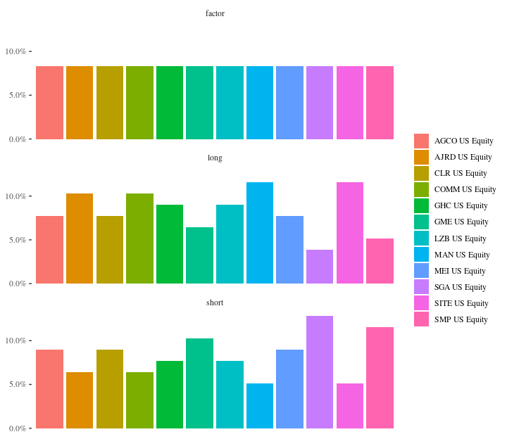

```r
plot(object = factor, type = "positions")
```

## references

Basu, Devraj, and Joëlle Miffre. 2013. “Capturing the Risk Premium of Commodity Futures: The Role of Hedging Pressure.” *Journal of Banking & Finance* 37 (7): 2652–64. https://doi.org/10.1016/j.jbankfin.2013.02.031.

Carhart, Mark M. 1997. “On Persistence in Mutual Fund Performance.” *The Journal of Finance* 52 (1): 57–82.

Cootner, Paul H. 1960. “Returns to Speculators: Telser Versus Keynes.” *Journal of Political Economy* 68 (4): 396–404. https://doi.org/10.1086/258347.

Fama, Eugene F., and Kenneth R. French. 2012. “Size, Value, and Momentum in International Stock Returns.” *Journal of Financial Economics* 105 (3): 457–72.

———. 1992. “The Cross-Section of Expected Stock Returns.” *The Journal of Finance* 47 (2): 427–65. https://doi.org/10.1111/j.1540-6261.1992.tb04398.x.

———. 1993. “Common Risk Factors in the Returns on Stocks and Bonds.” *Journal of Financial Economics* 33 (1): 3–56. https://doi.org/10.1016/0304-405X(93)90023-5.

———. 1995. “Size and Book-to-Market Factors in Earnings and Returns.” *The Journal of Finance* 50 (1): 131–55. https://doi.org/10.1111/j.1540-6261.1995.tb05169.x.

———. 1997. “Industry Costs of Equity.” *Journal of Financial Economics* 43 (2): 153–93. https://doi.org/10.1016/S0304-405X(96)00896-3.

———. 2015. “A Five-Factor Asset Pricing Model.” *Journal of Financial Economics* 116 (1): 1–22. https://doi.org/10.1016/j.jfineco.2014.10.010.

———. 2016. “Dissecting Anomalies with a Five-Factor Model.” *The Review of Financial Studies* 29 (1): 69–103. https://doi.org/10.1093/rfs/hhv043.

———. 2017. “International Tests of a Five-Factor Asset Pricing Model.” *Journal of Financial Economics* 123 (3): 441–63. https://doi.org/10.1016/j.jfineco.2016.11.004.

Fuertes, Ana-Maria, Joëlle Miffre, and Adrian Fernandez-Perez. 2015. “Commodity Strategies Based on Momentum, Term Structure, and Idiosyncratic Volatility.” *Journal of Futures Markets* 35 (3): 274–97. https://doi.org/10.1002/fut.21656.

Hicks, John Richard. 1939. *Value and Capital*. 1st ed. Oxford University Press, Cambridge.

Hong, Harrison, and Motohiro Yogo. 2012. “What Does Futures Market Interest Tell Us About the Macroeconomy and Asset Prices?” *Journal of Financial Economics* 105 (3): 473–90. https://doi.org/10.1016/j.jfineco.2012.04.005.

Houthakker, Hendrik. 1957. “Restatement of the Theory of Normal Backwardation.” Cowles Foundation Discussion Papers 44. Cowles Foundation for Research in Economics, Yale University. https://EconPapers.repec.org/RePEc:cwl:cwldpp:44.

Keynes, John Maynard. 1930. *Treatise on Money*. Macmillan, London.

Lintner, John. 1975. “The Valuation of Risk Assets and the Selection of Risky Investments in Stock Portfolios and Capital Budgets.” In *Stochastic Optimization Models in Finance*, 131–55. Elsevier.

Miffre, Joëlle, and Georgios Rallis. 2007. “Momentum Strategies in Commodity Futures Markets.” *Journal of Banking & Finance* 31 (6): 1863–86.

Mossin, Jan. 1966. “Equilibrium in a Capital Asset Market.” *Econometrica* 34 (4): 768–83. https://doi.org/10.2307/1910098.

Pástor, L’uboš, and Robert F Stambaugh. 2003. “Liquidity Risk and Expected Stock Returns.” *Journal of Political Economy* 111 (3): 642–85.

Sharpe, William F. 1964. “Capital Asset Prices: A Theory of Market Equilibrium Under Conditions of Risk.” *The Journal of Finance* 19 (3): 425–42.

Stambaugh, Robert F, and Yu Yuan. 2016. “Mispricing Factors.” *The Review of Financial Studies* 30 (4): 1270–1315.

Szymanowska, Marta, Frans De Roon, Theo Nijman, and Rob Van Den Goorbergh. 2014. “An Anatomy of Commodity Futures Risk Premia.” *The Journal of Finance* 69 (1): 453–82. https://doi.org/10.1111/jofi.12096.

Treynor, Jack L. 1961a. “Market Value, Time, and Risk.”

———. 1961b. *Toward a Theory of Market Value of Risky Assets*.